# Discovering Multiple Clustering Structures: A Step-by-Step Analysis

2025-07-27

# Introduction

This document demonstrates a novel approach for detecting and separating multiple independent clustering structures within high-dimensional data. We walk through a complete analysis of a single synthetic dataset designed to have two distinct clustering patterns in different subsets of dimensions.

## The Challenge

Traditional clustering algorithms assume a single clustering structure exists across all dimensions. However, real-world data often contains multiple, independent groupings. For instance: - Customer data might cluster by purchasing behaviour in some variables and by demographics in others - Gene expression data might show different clustering patterns for different biological pathways - Sensor data might have spatial patterns in some dimensions and temporal patterns in others

## Our Approach

We demonstrate a methodology that: 1. Applies clustering independently to each dimension 2. Measures similarity between these dimension-wise clusterings 3. Groups dimensions that share similar clustering patterns 4. Validates whether distinct clustering structures have been successfully identified

## Dataset Design

Our synthetic dataset contains: - **10 dimensions** total - **Structure 1**: 3 clusters present in dimensions 1-5 - **Structure 2**: 4 clusters present in dimensions 6-10 - **High separation** (6σ) to clearly demonstrate the methodology

This creates a challenging scenario where traditional clustering must choose which structure to optimise for, as both cannot be captured simultaneously.

# 1. Setup and Libraries

# 2. Data Generation

We create synthetic data where two independent clustering structures coexist in different dimensional subspaces.

```
## Dataset Configuration:
```

```
## - Total dimensions: 10
```

```
## - Structure 1: 3 clusters in dimensions 1-5
```

```
## - Structure 2: 4 clusters in dimensions 6-10
```

```
## - Separation factor: 6 standard deviations
```

```
## - Sample size: 50 observations
```

```
##
## Generating dataset with two independent clustering structures...
```

```
## Dataset created successfully.
```

```
## - Dimensions: 10
```

```
## - Samples: 50
```

# 3. Visualise the Challenge: Two Hidden Structures

This visualisation demonstrates the fundamental challenge: when data is ordered by one clustering structure, the other appears completely scrambled. This illustrates why traditional clustering methods fail to capture both structures simultaneously.

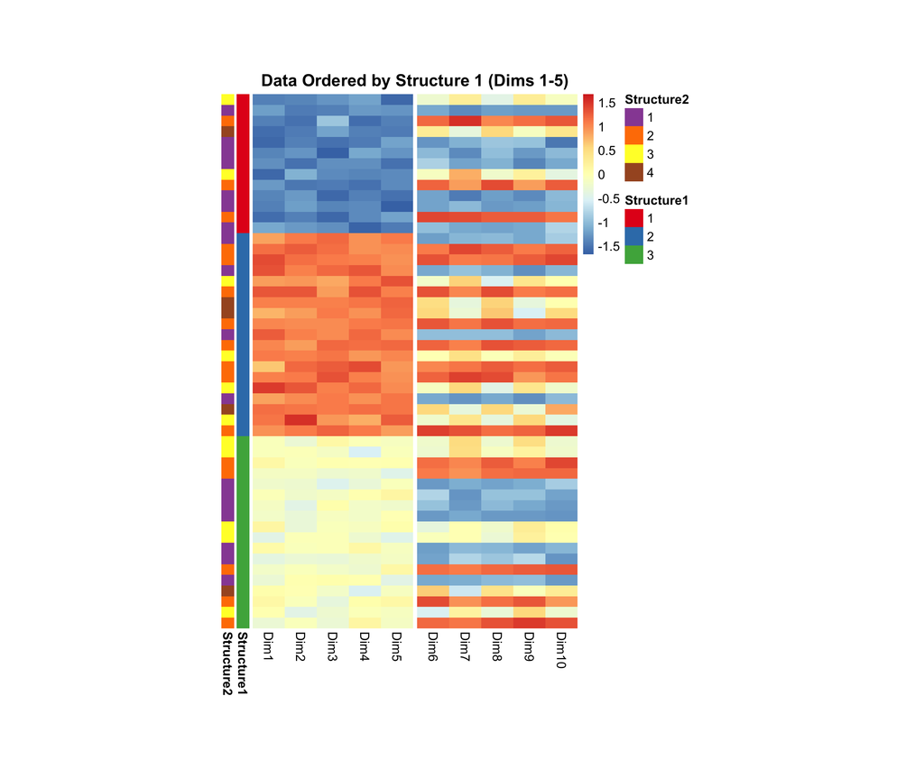

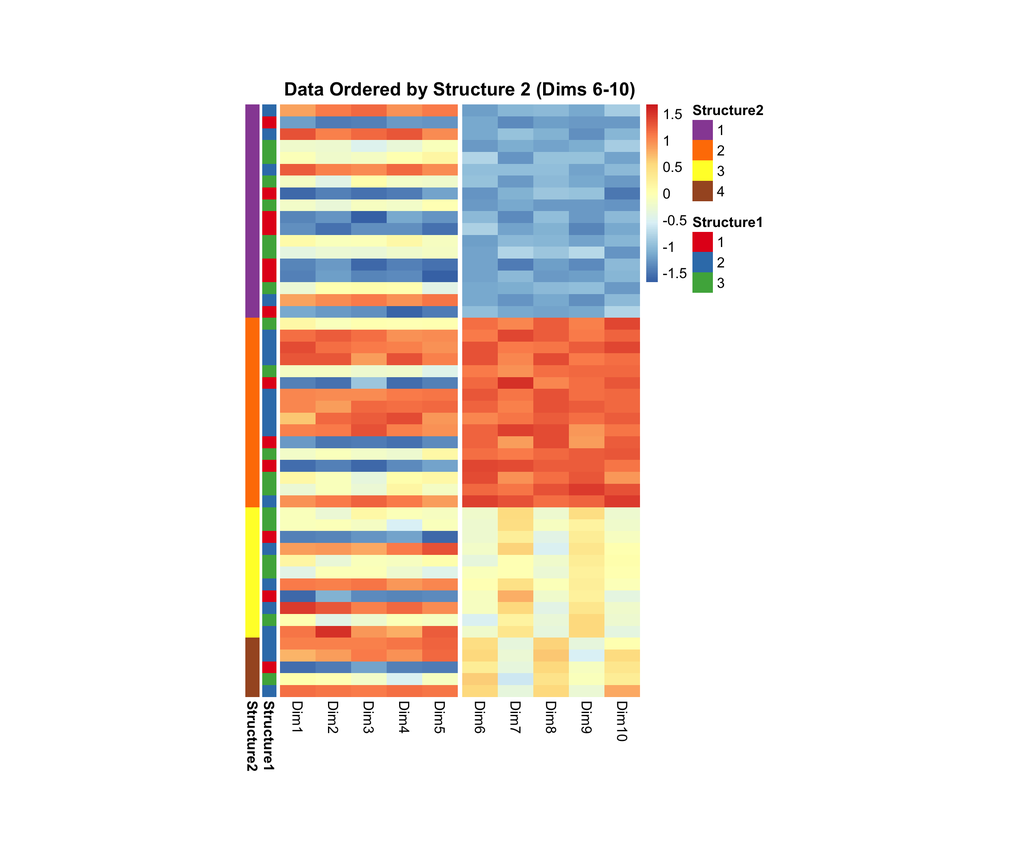

```
##
## Key Observation: When samples are ordered by Structure 1, the Structure 2 pattern
```

```
##
## in dimensions 6-10 appears scrambled (and vice versa). This demonstrates why
```

```
##
## traditional clustering cannot capture both structures simultaneously.
```

# 4. Step 1: Dimension-wise Clustering with MCLUST

We apply model-based clustering (MCLUST) to each dimension independently. This allows the Bayesian Information Criterion (BIC) to determine the optimal number of clusters for each dimension without prior knowledge.

```
##
## Applying MCLUST to each dimension independently...
```

```
## This allows automatic detection of cluster numbers via BIC.
```

```
## Dimension 1: 3 clusters detected (True: 3)
## Dimension 2: 3 clusters detected (True: 3)
## Dimension 3: 3 clusters detected (True: 3)
## Dimension 4: 3 clusters detected (True: 3)
## Dimension 5: 3 clusters detected (True: 3)
## Dimension 6: 4 clusters detected (True: 4)
## Dimension 7: 2 clusters detected (True: 4)
## Dimension 8: 4 clusters detected (True: 4)
## Dimension 9: 4 clusters detected (True: 4)
## Dimension 10: 4 clusters detected (True: 4)
```

```
##
## Detection accuracy: 9 out of 10 dimensions
```

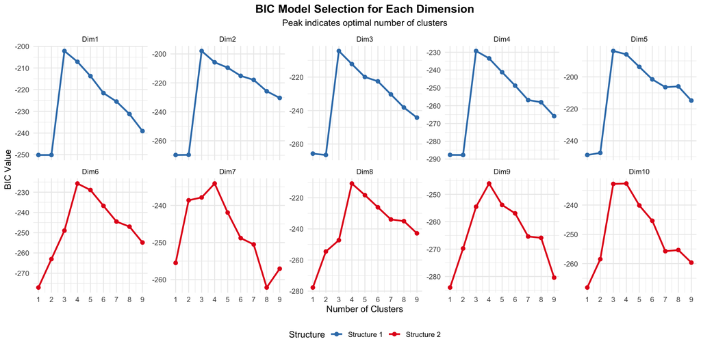

# 5. Step 2: Measure Clustering Similarity with ARI

We compute the Adjusted Rand Index (ARI) between all pairs of dimension-wise clusterings. High ARI values indicate similar clustering structures.

```
##
## Computing pairwise clustering similarity (ARI) between dimensions...
```

```
##
## ARI Summary:
```

```
## - Within Structure 1 (dims 1-5): 1
```

```
## - Within Structure 2 (dims 6-10): 0.785
```

```
## - Between structures: 0.002
```

```
##
## The near-zero between-structure ARI confirms the structures are independent.
```

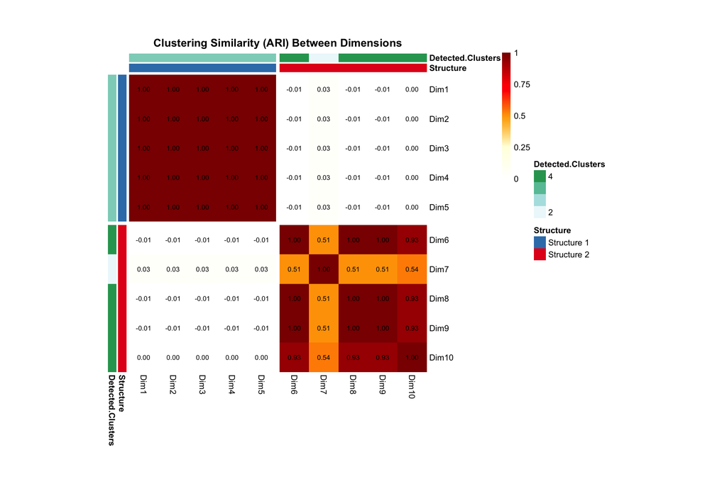

```
##
## The block structure is clearly visible: high similarity within each structure,
```

```
## near-zero similarity between structures.
```

# 6. Step 3: Group Dimensions Using Hierarchical Clustering

We use Hierarchical Clustering to cluster the dimensions based on their ARI dissimilarity. The optimal number of clusters is determined by maximising the average silhouette width.

```
##
## Applying Hierarchical clustering to group dimensions with similar clustering patterns...
```

```
##
##  Only frey, mcclain, cindex, sihouette and dunn can be computed. To compute the other indices, data matrix is needed
```

```
## Optimal Number of Clusters:
##  k = 4: Dunn Index = Inf
##
## Infinite Dunn Index -> Switching to Silhouette Index
##
##  k = 2: Average silhouette width = 0.891
##  k = 3: Average silhouette width = 0.871
##  k = 4: Average silhouette width = 0.800
##  k = 5: Average silhouette width = 0.500
##  k = 6: Average silhouette width = 0.500
## Optimal number of dimension groups: 2
```

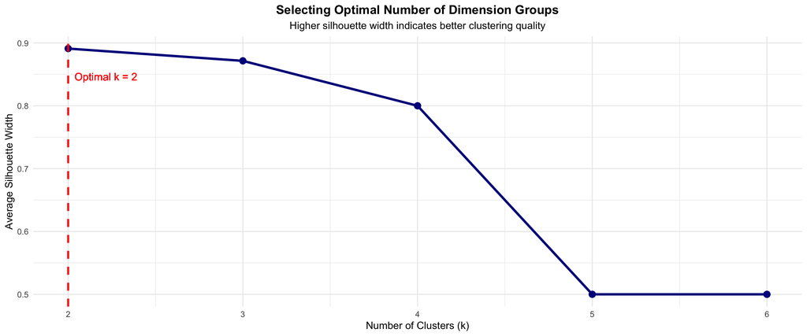

```
##
## Hierarchical Clustering Assignments:
```

```
## Group 1: Dim1, Dim2, Dim3, Dim4, Dim5
## Group 2: Dim6, Dim7, Dim8, Dim9, Dim10
```

# 7. Step 4: Validate Structure Recovery

We assess whether Hierarchical Clustering has successfully separated the two known structures.

```
##
##
## Validation Results:
```

```
## Structure 1 dimensions assigned to HClust cluster(s): 1
```

```
## Structure 2 dimensions assigned to HClust cluster(s): 2
```

```
##
## Recovery Performance (ARI): 1
```

```
##
## ✓ Perfect recovery! The two structures have been completely separated.
```

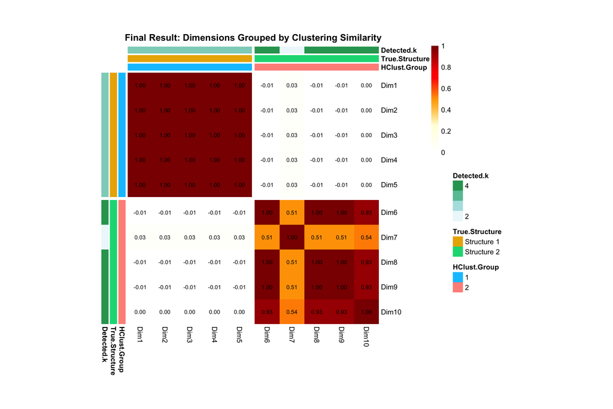

# 8. Step 5: Consensus Clustering with COCA

Now that we’ve identified which dimensions belong to each structure using Hiearchical clustering, we can use COCA (Cluster-Of-Clusters Analysis) to create a single consensus clustering for each discovered structure. This combines the information from multiple dimension-wise clusterings into a robust summary.

```
## HClust identified 2 dimension groups:
```

```
## Group 1 : Dim1 Dim2 Dim3 Dim4 Dim5
## Group 2 : Dim6 Dim7 Dim8 Dim9 Dim10
```

## 8.1 Build MOC and Apply COCA for Each Discovered Group

```
##
##
## === Analyzing Group 1 ===
## Dimensions in this group: Dim1 Dim2 Dim3 Dim4 Dim5
## Number of clusters in each dimension: 3, 3, 3, 3, 3
## MOC dimensions: 50 clusters × 15 observations
## Applying COCA with automatic K selection (maxK = 6 )
```

```
## [1] "K = 3"
##
## COCA selected K = 3 for Group 1
## Final cluster sizes: 18 13 19
## Mean consensus value: 0.328
## ARI with true Structure 1 labels: 1
## True K = 3 , COCA selected K = 3
##
##
## === Analyzing Group 2 ===
## Dimensions in this group: Dim6 Dim7 Dim8 Dim9 Dim10
## Number of clusters in each dimension: 4, 2, 4, 4, 4
## MOC dimensions: 50 clusters × 18 observations
## Applying COCA with automatic K selection (maxK = 6 )
## [1] "K = 4"
##
## COCA selected K = 4 for Group 2
## Final cluster sizes: 11 16 18 5
## Mean consensus value: 0.276
## ARI with true Structure 2 labels: 1
## True K = 4 , COCA selected K = 4
```

```
##
## Restored original consensusCluster function
```

## 8.2 Visualize Matrix Of Clusters (MOC)

```
##
## Group 1 MOC dimensions: 50 rows × 15 columns
## MOC has observations in rows and clusters in columns
```

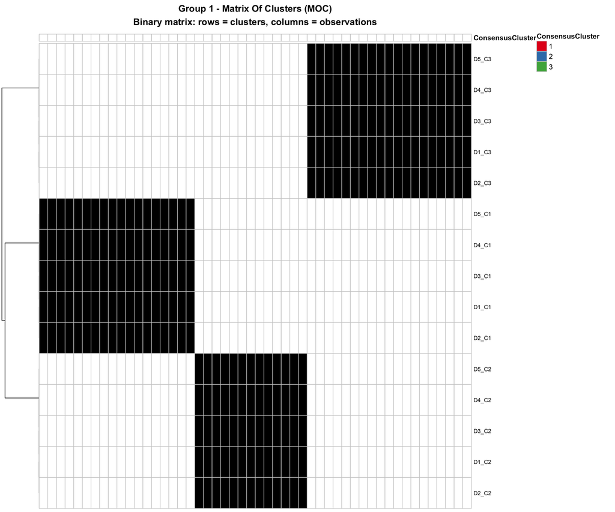

```
##
## Group 1 MOC summary:
## - Dimensions included: Dim1 Dim2 Dim3 Dim4 Dim5
## - Observations (rows): 50
## - Total clusters (columns): 15
## - Sparsity: 66.7 % zeros
##
## Group 2 MOC dimensions: 50 rows × 18 columns
## MOC has observations in rows and clusters in columns
```

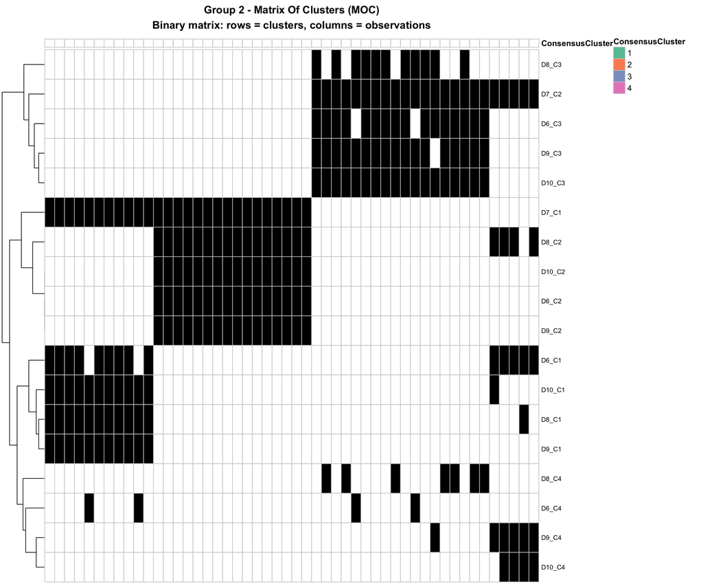

```
##
## Group 2 MOC summary:
## - Dimensions included: Dim6 Dim7 Dim8 Dim9 Dim10
## - Observations (rows): 50
## - Total clusters (columns): 18
## - Sparsity: 72.2 % zeros
```

```
##
##
## Note: buildMOC appears to return the MOC with observations in rows and
```

```
##
## clusters in columns, which is the transpose of the notation in the COCA paper.
```

## 8.3 Visualize COCA Consensus Matrices

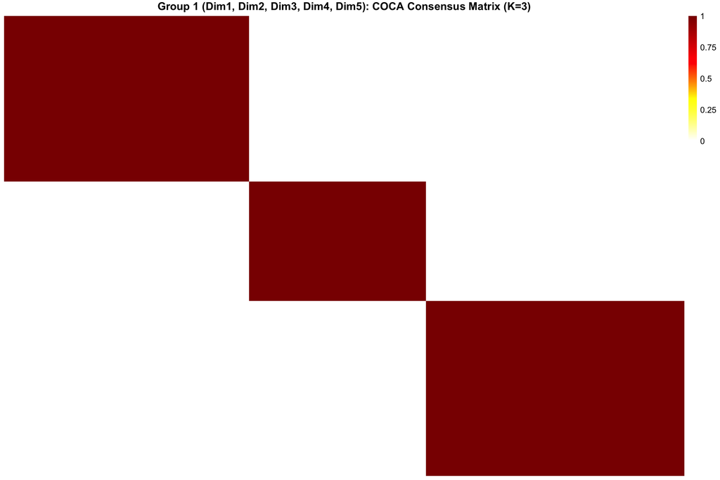

```
##
## Group 1 consensus clustering: 1 1 1 1 1 1 1 1 1 1 1 1 1 1 1 1 1 1 2 2 2 2 2 2 2 2 2 2 2 2 2 3 3 3 3 3 3 3 3 3 3 3 3 3 3 3 3 3 3 3
## Number of clusters: 3
## Cluster sizes: 18, 13, 19
```

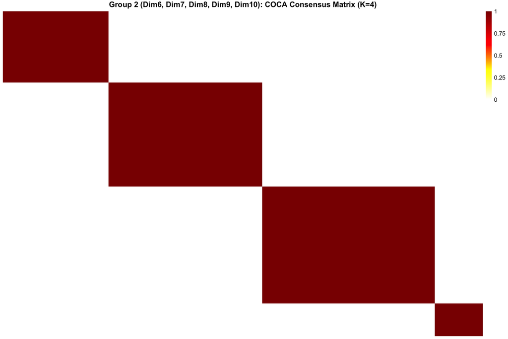

```
##
## Group 2 consensus clustering: 1 1 1 1 1 1 1 1 1 1 1 2 2 2 2 2 2 2 2 2 2 2 2 2 2 2 2 3 3 3 3 3 3 3 3 3 3 3 3 3 3 3 3 3 3 4 4 4 4 4
## Number of clusters: 4
## Cluster sizes: 11, 16, 18, 5
```

```
##
## The COCA consensus matrices show how often pairs of observations were
```

```
##
## clustered together across the consensus clustering iterations.
```

```
## Dark red indicates high consensus (often clustered together),
```

```
##
## white indicates low consensus (rarely clustered together).
```

## 8.4 Compare Dimension-wise vs COCA Consensus

Agreement between Individual Dimensions and COCA Consensus

| Group | Method | ARI with Consensus | k |
| --- | --- | --- | --- |
| 1 | Dim1 | 1.000 | 3 |
| 1 | Dim2 | 1.000 | 3 |
| 1 | Dim3 | 1.000 | 3 |
| 1 | Dim4 | 1.000 | 3 |
| 1 | Dim5 | 1.000 | 3 |
| 1 | COCA Consensus | 1.000 | 3 |
| 2 | Dim6 | 1.000 | 4 |
| 2 | Dim7 | 0.505 | 2 |
| 2 | Dim8 | 1.000 | 4 |
| 2 | Dim9 | 1.000 | 4 |
| 2 | Dim10 | 0.932 | 4 |
| 2 | COCA Consensus | 1.000 | 4 |

```
##
## The table shows how well individual dimension clusterings agree with
```

```
##
## the COCA consensus within each discovered group.
```

## 8.5 Final Visualization: All Consensus Clusterings

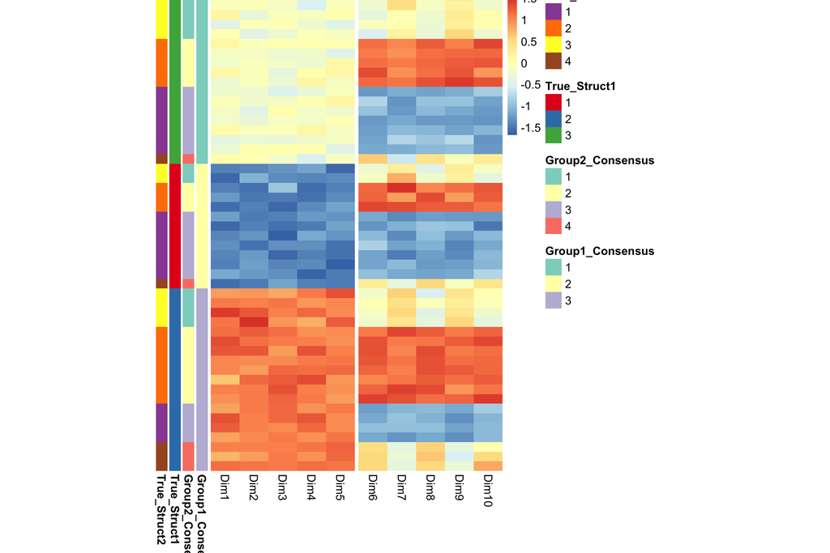

```
##
## The visualization shows the final COCA consensus clustering for each
```

```
##
## dimension group discovered by HClust clustering.
```

# 9. Summary: Complete Analysis Pipeline

Our complete methodology now includes:

1. **Dimension-wise Clustering**: Applied MCLUST to each dimension independently
2. **Similarity Assessment**: Computed pairwise ARI between dimension clusterings
3. **Dimension Grouping**: Used HClust to identify dimensions with similar patterns
4. **Structure Validation**: Confirmed successful separation of clustering structures
5. **Consensus Clustering**: Applied COCA to get a single robust clustering for each discovered group

## Final Results

```
## Summary of Results:
```

```
## 1. HClust discovered 2 dimension groups:
```

```
##    Group 1 : Dim1 Dim2 Dim3 Dim4 Dim5
##    Group 2 : Dim6 Dim7 Dim8 Dim9 Dim10
```

```
##
## 2. COCA consensus clustering for each group:
```

```
##    Group 1 : Found 3 clusters
##    Group 2 : Found 4 clusters
```

```
##
## 3. Validation against known structure:
##    Group 1 (Structure 1): ARI = 1
##    Group 2 (Structure 2): ARI = 1
```

## Benefits of the Complete Pipeline

- **Discovery**: Automatically identifies multiple clustering structures without prior knowledge
- **Interpretability**: Clear identification of which dimensions contribute to each structure
- **Robustness**: COCA consensus leverages agreement across multiple dimension-wise views
- **Actionability**: Provides a single clustering solution for each discovered structure

## Next Steps

To understand how this approach performs under more challenging conditions: - See `Example1g.Rmd` for a comprehensive simulation study - The simulation varies cluster separation from 6σ down to 0.5σ - Results show at what point cluster overlap prevents structure recovery

## Conclusion

By combining dimension grouping with COCA consensus clustering, we achieve both structure discovery and robust cluster assignment. This provides a complete solution for analyzing data with multiple independent clustering structures.